# 560-hw3

Jieyi Sun

3/3/2022

```r
library(tidyverse)
library(astsa)
library(forecast)
library(tseries)
library(lubridate)
```

1. Get the information that you obtained from your previous EDA about the stationarity of your time series.

Information obtained from

1. ACF graphs &
2. Using the Augmented Dickey-Fuller Test to check the stationarity.

Next, assuming that you have used log transformation (only if necessary) let’s continue. (Do not start differencing yet)

```r
BKNG<-read.csv("~/Desktop/560/560-website/hotel/BKNG_d.csv")
BKNG$Date=as.Date(BKNG$Date)
log.Adj.Close<-log(BKNG$Adj.Close)
data<-data.frame(BKNG$Date,BKNG$Adj.Close,log.Adj.Close)
colnames(data)<-c("Date", "Adj.Close", "log.Adj.Close")
```

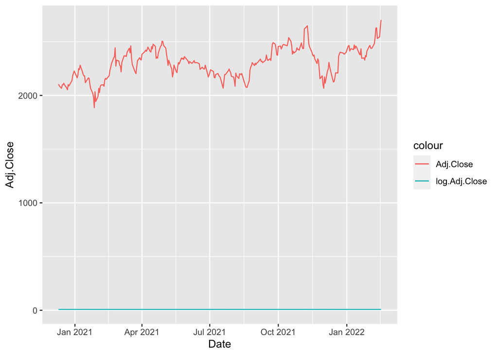

```r
data %>%
  ggplot()+
  geom_line(aes(x=Date,y=Adj.Close, colour="Adj.Close"))+
  geom_line(aes(x=Date,y=log.Adj.Close, colour="log.Adj.Close"))
```

2. Determine whether your data are stationary or non-stationary. (Remember ACF plots are more reliable than the ADF test)

If the data is already stationary then skip step 3 and go to step 4.

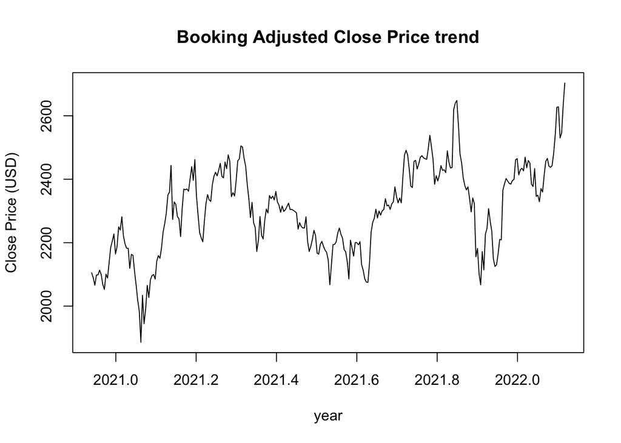

```r
ts_Adj.Close<-ts(BKNG$Adj.Close,start=decimal_date(as.Date("2020-12-10")),frequency = 253)
plot(ts_Adj.Close,xlab="year",ylab="Close Price (USD)", main="Booking Adjusted Close Price trend")
```

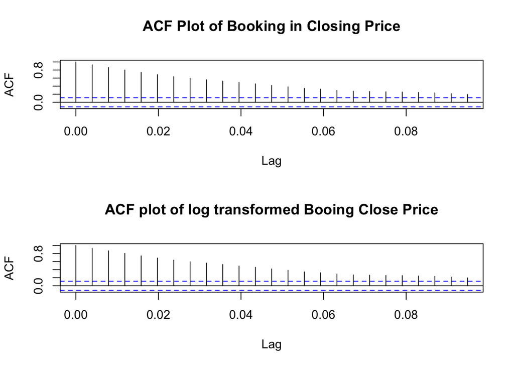

```r
par(mfrow = c(2,1))
acf(ts_Adj.Close, main="ACF Plot of Booking in Closing Price") #high correlation
log_Close<-log(ts_Adj.Close) # log transformation
acf(log_Close, main="ACF plot of log transformed Booing Close Price")
```

```r
adf.test(ts_Adj.Close) #p-value is greater than 0.05, not stationary
```

```
##
##  Augmented Dickey-Fuller Test
##
## data:  ts_Adj.Close
## Dickey-Fuller = -2.5868, Lag order = 6, p-value = 0.3289
## alternative hypothesis: stationary
```

```r
adf.test(log_Close) #still not stationary
```

```
##
##  Augmented Dickey-Fuller Test
##
## data:  log_Close
## Dickey-Fuller = -2.6484, Lag order = 6, p-value = 0.303
## alternative hypothesis: stationary
```

3. If your data (or log transformed data) are non-stationary then:

(a). Difference the (transformed) time series data until it is stationary/weakly stationary.